# Retail Campaign Effectiveness

- Show All Code
- Hide All Code
- View Source

Author

Tilabo Williamson

Published

October 25, 2026

# Background

Retailers often invest in **direct-marketing campaigns**, such as coupons. The business question is simple: do these campaigns actually change what households buy?

> **Question for this project:** Did these campaigns increase household spend, and did all household types respond in the same way?

This first part of the project explains the data, checks its quality and describes how households shop. Later parts will measure the effect of the campaigns themselves.

## About the data

The data covers two years of grocery shopping by 2500 households who shop regularly at one U.S. retailer. It records every product they bought, as well as which households were targeted by 30 direct-marketing campaigns and which coupons were redeemed.

```r
# Reading in the data
transactions  <- read_csv("data/raw/transaction_data.csv") %>%
  clean_names()
products      <- read_csv("data/raw/product.csv") %>%
  clean_names()
demographics  <- read_csv("data/raw/hh_demographic.csv") %>%
  clean_names()
campaign_desc <- read_csv("data/raw/campaign_desc.csv") %>%
  clean_names()
campaign_hh   <- read_csv("data/raw/campaign_table.csv") %>%
  clean_names()
redemptions   <- read_csv("data/raw/coupon_redempt.csv") %>%
  clean_names()
```

Six data sets are examined in this analysis. The transactions data set is by far the largest and is the focus.

```r
# Data set summary
tables_used <- tibble(
  Table = c("transactions", "products", "demographics",
            "campaign_desc", "campaign_hh", "redemptions"),
  `What it holds` = c(
    "Every product bought, one row per product per receipt",
    "Product details such as department and brand",
    "Age, income and household size (some households only)",
    "The 30 campaigns and their start and end days",
    "Which households were targeted by which campaign",
    "Which households redeemed a coupon, and when"
  ),
  Rows = big(c(nrow(transactions), nrow(products), nrow(demographics),
               nrow(campaign_desc), nrow(campaign_hh), nrow(redemptions)))
)

# Display in kable
tables_used %>%
  kable(caption = "The six data sets used in this report", align = c("l", "l", "r")) %>%
  style_table()
```

The six data sets used in this report

| Table | What it holds | Rows |
| --- | --- | --- |
| transactions | Every product bought, one row per product per receipt | 2,595,732 |
| products | Product details such as department and brand | 92,353 |
| demographics | Age, income and household size (some households only) | 801 |
| campaign_desc | The 30 campaigns and their start and end days | 30 |
| campaign_hh | Which households were targeted by which campaign | 7,208 |
| redemptions | Which households redeemed a coupon, and when | 2,318 |

### Key terms

- **Household:** one shopping household, identified by a household key.
- **Basket:** one shopping trip. All line items bought together share the same basket ID.
- **Line item:** one product on one receipt. Each row of the transactions table is a line item.
- **Campaign:** a direct-marketing effort sent to chosen households, usually with coupons.

### Variables in the transactions data set

```r
# What each column in the transactions table means
variable_dictionary <- tibble(
  Variable = c("household_key", "basket_id", "day", "week_no", "product_id",
               "store_id", "quantity", "sales_value", "retail_disc",
               "coupon_disc", "coupon_match_disc", "trans_time"),
  Meaning = c(
    "Unique ID for the household that shopped",
    "Unique ID for one shopping trip; links all items bought together",
    "Day of the purchase, counted from the start of the data",
    "Week of the purchase, counted from the start of the data",
    "Unique ID for the product; links to the products table",
    "Store where the purchase was made",
    "Number of units of that product bought on that line",
    "Money the retailer received for that line, in dollars",
    "Discount from the retailer's loyalty-card programme (stored as a negative number)",
    "Discount from a manufacturer coupon",
    "Discount from the retailer matching a manufacturer coupon",
    "Time of day of the purchase on a 24-hour clock (1631 = 4:31 pm)"
  )
)

# Display in kable
variable_dictionary %>%
  kable(caption = "Variable dictionary: transactions table") %>%
  style_table()
```

Variable dictionary: transactions table

| Variable | Meaning |
| --- | --- |
| household_key | Unique ID for the household that shopped |
| basket_id | Unique ID for one shopping trip; links all items bought together |
| day | Day of the purchase, counted from the start of the data |
| week_no | Week of the purchase, counted from the start of the data |
| product_id | Unique ID for the product; links to the products table |
| store_id | Store where the purchase was made |
| quantity | Number of units of that product bought on that line |
| sales_value | Money the retailer received for that line, in dollars |
| retail_disc | Discount from the retailer's loyalty-card programme (stored as a negative number) |
| coupon_disc | Discount from a manufacturer coupon |
| coupon_match_disc | Discount from the retailer matching a manufacturer coupon |
| trans_time | Time of day of the purchase on a 24-hour clock (1631 = 4:31 pm) |

# Data Quality

Before describing or analysing the data, it was checked that it is complete, free of duplicates and free of values that would distort the results.

## Missingness

First the data was examined for missingness.

```r
# Count missing values in each column
missing_wide <- transactions %>%
  summarise(across(everything(), ~ sum(is.na(.x))))

# Turn the wide row into a long table, one row per column
missing_long <- missing_wide %>%
  pivot_longer(
    cols      = everything(),
    names_to  = "Column",
    values_to = "Missing values"
  )

# Display in kable
missing_long %>%
  kable(caption = "Missing values per column in the transactions table") %>%
  style_table()
```

Missing values per column in the transactions table

| Column | Missing values |
| --- | --- |
| household_key | 0 |
| basket_id | 0 |
| day | 0 |
| product_id | 0 |
| quantity | 0 |
| sales_value | 0 |
| store_id | 0 |
| retail_disc | 0 |
| trans_time | 0 |
| week_no | 0 |
| coupon_disc | 0 |
| coupon_match_disc | 0 |

Across all 12 columns of the `transactions` data set, all columns have 0 rows containing missing data.

## Duplications

Next we examined the transaction data set for rows that were duplicates.

```r
# Count of any duplicate rows
n_duplicates <- sum(duplicated(transactions))

cat("Number of duplicate rows:", n_duplicates, "\n")
```

```
Number of duplicate rows: 0
```

The `transactions` data set contained **0** duplicate rows.

## Data counts

The next table shows the counts of key variables in the transaction data set.

```r
# Counts of people, baskets, products, stores, time
data_counts <- transactions %>%
  summarise(
    households = n_distinct(household_key),
    baskets    = n_distinct(basket_id),
    products   = n_distinct(product_id),
    stores     = n_distinct(store_id),
    first_day  = min(day),
    last_day   = max(day),
    first_week = min(week_no),
    last_week  = max(week_no)
  )

# Turn the wide row into a long table, one row per column
data_counts_long <- data_counts %>%
  pivot_longer(
    cols      = everything(),
    names_to  = "Column",
    values_to = "Data Counts"
  )

# Display in kable
data_counts_long %>%
  kable(caption = "Counts of key variables from the transaction dataset") %>%
  style_table()
```

Counts of key variables from the transaction dataset

| Column | Data Counts |
| --- | --- |
| households | 2500 |
| baskets | 276484 |
| products | 92339 |
| stores | 582 |
| first_day | 1 |
| last_day | 711 |
| first_week | 1 |
| last_week | 102 |

## Sales and quantity values

Checks for zero or negative sales and zero quantities, which can distort spend totals..

```r
# Sales and quantity values
sales_quantity_values <- transactions %>%
  summarise(
    zero_sales             = sum(sales_value == 0),
    negative_value_sales   = sum(sales_value < 0),
    zero_quantity          = sum(quantity == 0),
    min_sales              = min(sales_value),
    max_sales              = max(sales_value)
  )

# Turn the wide row into a long table, one row per column
sales_quantity_values_wide <- sales_quantity_values %>%
  pivot_longer(
    cols      = everything(),
    names_to  = "Column",
    values_to = "Values"
  )

# Display in kable
sales_quantity_values_wide %>%
  kable(caption = "Sales and quantity values") %>%
  style_table()
```

Sales and quantity values

| Column | Values |
| --- | --- |
| zero_sales | 18850 |
| negative_value_sales | 0 |
| zero_quantity | 14466 |
| min_sales | 0 |
| max_sales | 840 |

There are no negative sales values, so no returns or refunds are recorded as negative sales. However, **18,850** lines (0.73% of all lines) have a sales value of zero, and **14,466** lines (0.56%) have a quantity of zero.

**What this means for the analysis:**

- **Spend:** Lines with zero sales add nothing to a household’s total spend, so they don’t distort spend totals.
- **Averages per line:** They do pull the average line value down slightly, because they count as lines. Household and basket totals are not affected.
- **Units:** A quantity of zero can’t be used to work out a price per unit, because dividing by zero gives an error. Quantity is not used for that in this report.
- **Scale:** Both groups are under 1% of the data, so the main results are very unlikely to change. These rows are kept in, and flagged here for transparency.

## Demographic coverage

Shows how many shoppers have demographic details, which limits every analysis by age, income or household size to that subset.

```r
# What share of shoppers have demographic information?
households_in_transactions <- n_distinct(transactions$household_key)
households_in_demographics <- n_distinct(demographics$household_key)

cat("Number of households in the transaction data set:", households_in_transactions, "\n")
```

```
Number of households in the transaction data set: 2500
```

```r
cat("Number of households in the transaction data set:", households_in_demographics, "\n")
```

```
Number of households in the transaction data set: 801
```

```r
cat("Share of shoppers that have transaction and demographic data:", households_in_demographics / households_in_transactions, "\n")
```

```
Share of shoppers that have transaction and demographic data: 0.3204
```

# Descriptive Statistics

Basic statistics that describe the data.

## Line-item summary

Summarises the size and spread of each purchase line, which shows how skewed spending is before any grouping.

```r
# Put sales and quantity in one long column so we can summarise both at once
line_item_summary <- transactions %>%
  select(sales_value, quantity) %>%
  pivot_longer(cols = everything(), names_to = "Variable", values_to = "Value") %>%
  group_by(Variable) %>%
  summarise(
    `Mean (SD)` = paste0(round(mean(Value), 2), " (", round(sd(Value), 2), ")"),
    Median      = round(median(Value), 2),
    Min         = min(Value),
    Max         = max(Value)
  )

# Display in kable
line_item_summary %>%
  kable(caption = "Line-item summary: sales value and quantity") %>%
  style_table()
```

Line-item summary: sales value and quantity

| Variable | Mean (SD) | Median | Min | Max |
| --- | --- | --- | --- | --- |
| quantity | 100.43 (1153.44) | 1 | 0 | 89638 |
| sales_value | 3.1 (4.18) | 2 | 0 | 840 |

The typical line item is worth **$2.00** (median).

## Household totals

Builds one row per household (total spend, number of trips, average basket value), because most later analyses compare households, not single purchases.

```r
# Total sales value and number of baskets for each household
household_totals <- transactions %>%
  group_by(household_key) %>%
  summarise(
    total_spend = sum(sales_value),
    trips       = n_distinct(basket_id)
  ) %>%
  mutate(avg_basket_value = total_spend / trips)   # average spend per trip

# Show the first five households as a check
household_totals %>%
  head(5) %>%
  mutate(
    total_spend      = usd2(total_spend),
    avg_basket_value = usd2(avg_basket_value)
  ) %>%
  kable(caption = "First five households",
        col.names = c("Household", "Total spend", "Trips", "Average basket value"),
        align = c("l", "r", "r", "r")) %>%
  style_table()
```

First five households

| Household | Total spend | Trips | Average basket value |
| --- | --- | --- | --- |
| 1 | $4,330.16 | 86 | $50.35 |
| 2 | $1,954.34 | 45 | $43.43 |
| 3 | $2,653.21 | 47 | $56.45 |
| 4 | $1,200.11 | 30 | $40.00 |
| 5 | $779.06 | 40 | $19.48 |

- **Total spend:** everything the household spent over the two years.
- **Trips:** the number of separate shopping trips (baskets).
- **Average basket value:** total spend divided by trips.

## Distribution of household measures

Shows how total spend, number of trips and average basket value vary across households, so you can see at a glance whether households are similar or very different.

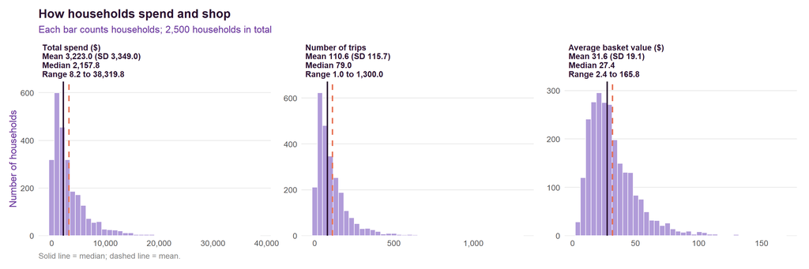

```r
# Create long data
household_long <- household_totals %>%
  select(total_spend, trips, avg_basket_value) %>%
  pivot_longer(cols = everything(), names_to = "Variable", values_to = "Value") %>%
  mutate(Variable = factor(Variable, levels = c("total_spend", "trips", "avg_basket_value")))

# Work out the summary numbers for each measure
household_stats <- household_long %>%
  group_by(Variable) %>%
  summarise(
    mean   = mean(Value),
    sd     = sd(Value),
    median = median(Value),
    min    = min(Value),
    max    = max(Value)
  )

# Build the label shown above each panel (name, mean (SD), median, range)
household_stats <- household_stats %>%
  mutate(
    Title = recode(as.character(Variable),
                   total_spend      = "Total spend ($)",
                   trips            = "Number of trips",
                   avg_basket_value = "Average basket value ($)"),
    Label = paste0(Title,
                   "\nMean ",   scales::comma(mean, accuracy = 0.1), " (SD ", scales::comma(sd, accuracy = 0.1), ")",
                   "\nMedian ", scales::comma(median, accuracy = 0.1),
                   "\nRange ",  scales::comma(min, accuracy = 0.1), " to ", scales::comma(max, accuracy = 0.1))
  )

# Link each panel to its label
panel_labels <- setNames(household_stats$Label, as.character(household_stats$Variable))

# Produce the three histograms side by side
household_long %>%
  ggplot(aes(x = Value)) +
  geom_histogram(bins = 40, fill = lavender, colour = "white") +
  geom_vline(data = household_stats, aes(xintercept = median),
             colour = deeppurple, linewidth = 1) +
  geom_vline(data = household_stats, aes(xintercept = mean),
             colour = coral, linewidth = 1, linetype = "dashed") +
  facet_wrap(~ Variable, scales = "free", nrow = 1,
             labeller = as_labeller(panel_labels)) +
  scale_x_continuous(labels = big) +
  scale_y_continuous(labels = big, expand = expansion(mult = c(0, 0.08))) +
  labs(
    title    = "How households spend and shop",
    subtitle = paste0("Each bar counts households; ", big(nrow(household_totals)), " households in total"),
    x        = NULL,
    y        = "Number of households",
    caption  = "Solid line = median; dashed line = mean."
  ) +
  theme_report +
  theme(
    strip.text    = element_text(face = "bold", colour = deeppurple, hjust = 0, size = 11),
    panel.spacing = unit(1.2, "lines")
  )
```

## Household summary

Shows the typical household’s spend, trips and basket size, with how much they vary, which sets the baseline for judging campaign effects.

```r
# Same summary as before, now at household level
household_summary <- household_totals %>%
  select(total_spend, trips, avg_basket_value) %>%
  pivot_longer(cols = everything(), names_to = "Variable", values_to = "Value") %>%
  group_by(Variable) %>%
  summarise(
    `Mean (SD)` = paste0(round(mean(Value), 2), " (", round(sd(Value), 2), ")"),
    Median      = round(median(Value), 2),
    Min         = round(min(Value), 2),
    Max         = round(max(Value), 2)
  )

# Display in kable
household_summary %>%
  kable(caption = "Household summary") %>%
  style_table()
```

Household summary

| Variable | Mean (SD) | Median | Min | Max |
| --- | --- | --- | --- | --- |
| avg_basket_value | 31.62 (19.05) | 27.42 | 2.39 | 165.83 |
| total_spend | 3222.99 (3349.03) | 2157.75 | 8.17 | 38319.79 |
| trips | 110.59 (115.67) | 79.00 | 1.00 | 1300.00 |

## Distribution of household spend

A typical household spent **$2,158** over the two years (median). The chart shows whether most households spend a similar amount or a few spend far more. If the mean sits to the right of the median, a few heavy spenders are pulling the average up.

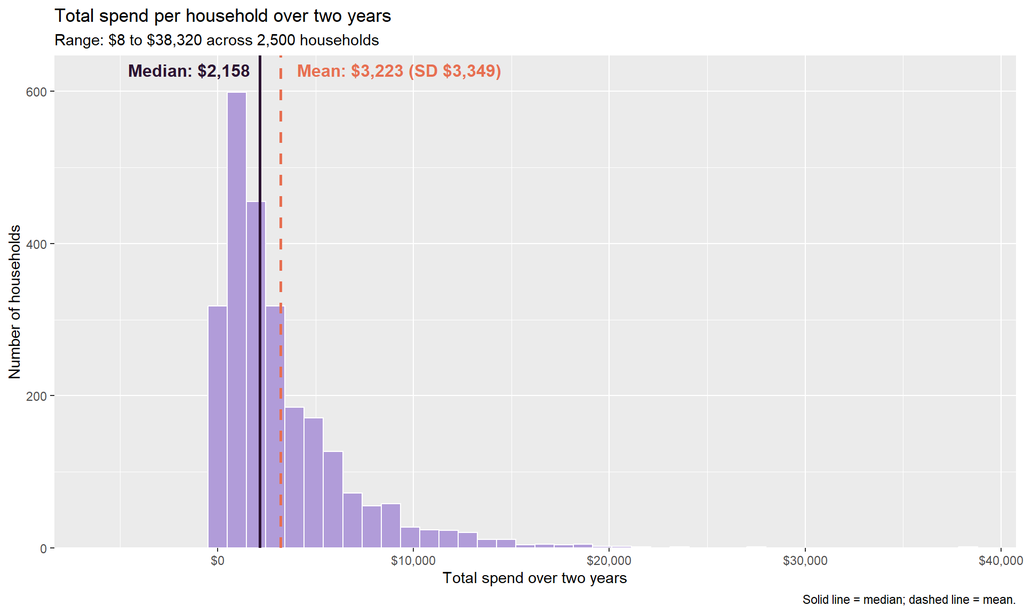

```r
# Summary numbers used to label the chart
spend_mean   <- mean(household_totals$total_spend)
spend_sd     <- sd(household_totals$total_spend)
spend_median <- median(household_totals$total_spend)
spend_min    <- min(household_totals$total_spend)
spend_max    <- max(household_totals$total_spend)

household_totals %>%
  ggplot(aes(x = total_spend)) +
  geom_histogram(bins = 40, fill = lavender, colour = "white") +
  geom_vline(xintercept = spend_median, colour = deeppurple, linewidth = 1) +
  geom_vline(xintercept = spend_mean, colour = coral, linewidth = 1, linetype = "dashed") +
  annotate("text", x = spend_median, y = Inf, hjust = 1.08, vjust = 1.6,
           label = paste0("Median: ", usd0(spend_median)),
           colour = deeppurple, fontface = "bold", size = 4.2) +
  annotate("text", x = spend_mean, y = Inf, hjust = -0.08, vjust = 1.6,
           label = paste0("Mean: ", usd0(spend_mean), " (SD ", usd0(spend_sd), ")"),
           colour = coral, fontface = "bold", size = 4.2) +
  scale_x_continuous(expand = expansion(mult = c(0.2, 0.05)),labels = usd0) +
  scale_y_continuous(labels = big, expand = expansion(mult = c(0, 0.08))) +
  labs(
    title    = "Total spend per household over two years",
    subtitle = paste0("Range: ", usd0(spend_min), " to ", usd0(spend_max),
                      " across ", big(nrow(household_totals)), " households"),
    x        = "Total spend over two years",
    y        = "Number of households",
    caption  = "Solid line = median; dashed line = mean."
  )
```

## Distribution of basket value

Shows how much a typical shopping trip is worth, and how skewed trip size is.

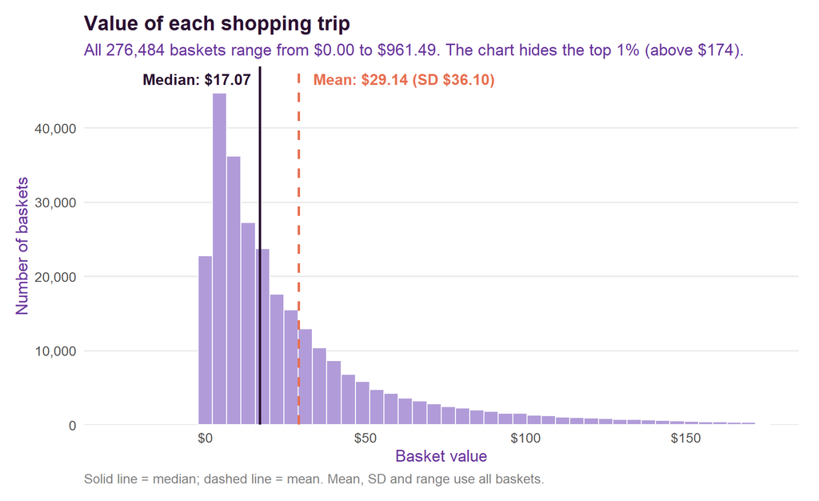

```r
# Total value of each basket (one shopping trip)
basket_values <- transactions %>%
  group_by(basket_id) %>%
  summarise(basket_value = sum(sales_value))

# Summary numbers use ALL baskets
basket_mean   <- mean(basket_values$basket_value)
basket_sd     <- sd(basket_values$basket_value)
basket_median <- median(basket_values$basket_value)
basket_min    <- min(basket_values$basket_value)
basket_max    <- max(basket_values$basket_value)

# Cut off the top 1% of baskets in the chart only, so a few huge baskets do not squash it
cutoff <- quantile(basket_values$basket_value, 0.99)

basket_values %>%
  filter(basket_value <= cutoff) %>%
  ggplot(aes(x = basket_value)) +
  geom_histogram(bins = 40, fill = lavender, colour = "white") +
  geom_vline(xintercept = basket_median, colour = deeppurple, linewidth = 1) +
  geom_vline(xintercept = basket_mean, colour = coral, linewidth = 1, linetype = "dashed") +
  annotate("text", x = basket_median, y = Inf, hjust = 1.08, vjust = 1.6,
           label = paste0("Median: ", usd2(basket_median)),
           colour = deeppurple, fontface = "bold", size = 4.2) +
  annotate("text", x = basket_mean, y = Inf, hjust = -0.08, vjust = 1.6,
           label = paste0("Mean: ", usd2(basket_mean), " (SD ", usd2(basket_sd), ")"),
           colour = coral, fontface = "bold", size = 4.2) +
  scale_x_continuous(expand = expansion(mult = c(0.2, 0.05)), labels = usd0) +
  scale_y_continuous(labels = big, expand = expansion(mult = c(0, 0.08))) +
  labs(
    title    = "Value of each shopping trip",
    subtitle = paste0("All ", big(nrow(basket_values)), " baskets range from ",
                      usd2(basket_min), " to ", usd2(basket_max),
                      ". The chart hides the top 1% (above ", usd0(cutoff), ")."),
    x        = "Basket value",
    y        = "Number of baskets",
    caption  = "Solid line = median; dashed line = mean. Mean, SD and range use all baskets."
  ) +
  theme_report
```

## Weekly sales over time

Shows the trend and seasonality in total sales, which any campaign comparison needs to allow for.

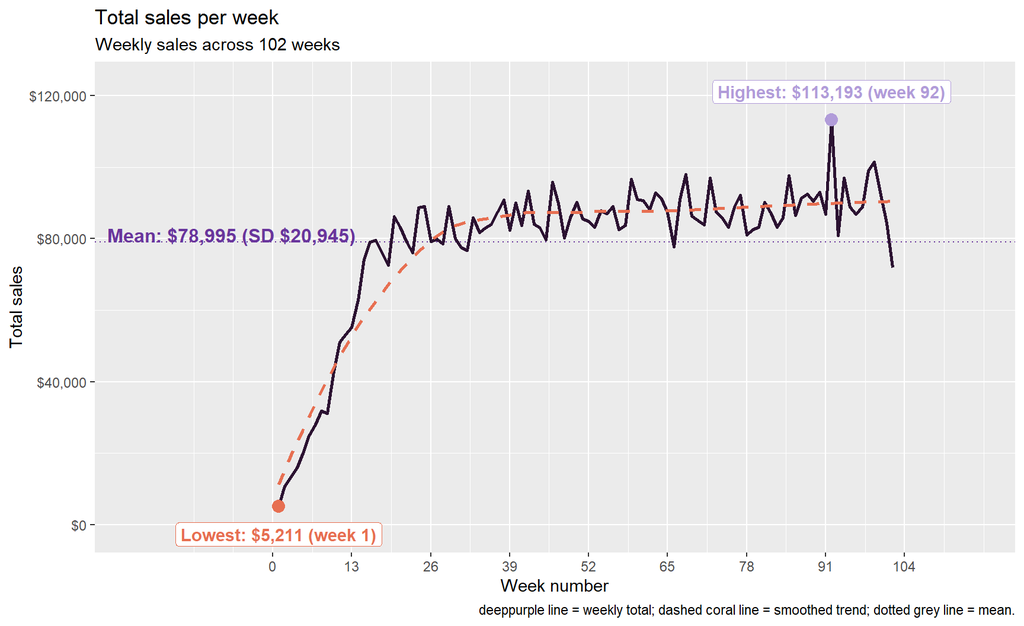

```r
# Total sales for every week in the data
weekly_sales <- transactions %>%
  group_by(week_no) %>%
  summarise(weekly_sales = sum(sales_value))

# Summary numbers and the best and worst weeks, used for labels
weekly_mean <- mean(weekly_sales$weekly_sales)
weekly_sd   <- sd(weekly_sales$weekly_sales)
peak_week   <- weekly_sales %>% slice_max(weekly_sales, n = 1)
low_week    <- weekly_sales %>% slice_min(weekly_sales, n = 1)

weekly_sales %>%
  ggplot(aes(x = week_no, y = weekly_sales)) +
  geom_hline(yintercept = weekly_mean, colour = purple, linetype = "dotted") +
  geom_line(colour = deeppurple, linewidth = 0.9) +
  geom_smooth(method = "loess", formula = y ~ x, se = FALSE,
              colour = coral, linetype = "dashed", linewidth = 0.9) +
  geom_point(data = peak_week, colour = lavender, size = 3.5) +
  geom_point(data = low_week, colour = coral, size = 3.5) +
  geom_label(data = peak_week, vjust = -0.7, colour = lavender, fontface = "bold",
             aes(label = paste0("Highest: ", usd0(weekly_sales), " (week ", week_no, ")"))) +
  geom_label(data = low_week, vjust = 1.7, colour = coral, fontface = "bold",
             aes(label = paste0("Lowest: ", usd0(weekly_sales), " (week ", week_no, ")"))) +
  annotate("text", x = -Inf, y = weekly_mean, hjust = -0.05, vjust = 0,
           label = paste0("Mean: ", usd0(weekly_mean), " (SD ", usd0(weekly_sd), ")"),
           colour = purple, fontface = "bold", size = 4.2) +
  scale_x_continuous(expand = expansion(mult = c(0.3, 0.2)), breaks = seq(0, 104, by = 13)) +
  scale_y_continuous(labels = usd0, expand = expansion(mult = c(0.12, 0.15))) +
  labs(
    title    = "Total sales per week",
    subtitle = paste0("Weekly sales across ", nrow(weekly_sales), " weeks"),
    x        = "Week number",
    y        = "Total sales",
    caption  = "deeppurple line = weekly total; dashed coral line = smoothed trend; dotted grey line = mean."
  )
```